# Topic 1 Lab

Xue(Tracy) Feng

## Preparation

```r
# Load packages used in this session of R
library(tidyverse)
library(knitr)
library(ggplot2)
library(plyr)

# As needed, set path to folder where data is located.
opts_knit$set(root.dir = "C:/Users/Xue Feng/Desktop/OPIM606/OPIM606_Lab1")
```

#### 1) Load the World Values Survey data from “Data/WV_small.csv” and the CountryCode data from “Data/Country codes for WVS wave 6.csv”

The codebook for the World Values Survey data is available at http://www.worldvaluessurvey.org/WVSDocumentationWV6.jsp

The variables in WV_small were created as follows:

- Satisfaction with your life from 1 (completely dissatisfied) to 10 (completely satisfied) (*V23*)
- Income: a country-specific scale ranging from 1 (lowest income category) to 10 (highest income category) (*V239* in the dataset)
- Education: a scale ranging from 1 (no formal education) to 9 (a degree from a university) (*V248* in the dataset)
- Country: based on *V2* in the dataset. See “Country codes for WVS wave 6.csv”
- Conservatism: self-identified political conservatism from 1 (most liberal) to 10 (most conservative) (*V95* in the data set)
- Male: a dummy variable indicating male (*V240*)
- Religious: Indicating how often the individual attends religious services ranging from 1 (almost never) to 7 (more than once a week) (this is a re-coding of *V145* that had the polarity reversed, but is harder to interpret)
- Marital: Marital status 1 = Married 2 = Living together as married 3 = Divorced 4 = Separated 5 = Widowed 6 = Single
- Survey year: year survey taken
- Birth year: respondents’s year of birth

```r
# read data
countryCodes <- read_csv("Country codes for WVS wave 6.csv")
wv <- read_csv("WV_small.csv")
# # global variables
# BrazilData <- wv %>%
#   filter(Country == "76")
#
# RussiaData <- wv %>%
#   filter(Country == "643")
#
# USData <- wv %>%
#   filter(Country == "840")
```

#### 2) What are the country codes for Brazil, Russia and the United States?

```r
# solution1
countryCodes[countryCodes$country == "Brazil", ]
```

```
## # A tibble: 1 x 2
##      V2 country
##   <dbl> <chr>
## 1    76 Brazil
```

```r
countryCodes[countryCodes$country == "Russia", ]
```

```
## # A tibble: 1 x 2
##      V2 country
##   <dbl> <chr>
## 1   643 Russia
```

```r
countryCodes[countryCodes$country == "United States", ]
```

```
## # A tibble: 1 x 2
##      V2 country
##   <dbl> <chr>
## 1   840 United States
```

```r
# solution2: Use dplyr
countryCodesAnswer <- countryCodes %>%
  filter(country == "Brazil" | country == "Russia" | country == "United States")
countryCodesAnswer
```

```
## # A tibble: 3 x 2
##      V2 country
##   <dbl> <chr>
## 1    76 Brazil
## 2   643 Russia
## 3   840 United States
```

#### 3) Create three dummy variables: one for observations from Brazil, one for observations from Russia and one for observations from the U.S. What types of variables are these? How many observations are from each country?

```r
# dummy variables
wv$BrazilDummy <- ifelse(wv$Country == "76", 1, 0)
wv$RussiaDummy <- ifelse(wv$Country == "643", 1, 0)
wv$UnitedStatesDummy <- ifelse(wv$Country == "840", 1, 0)

# type
typeof(wv$BrazilDummy)
```

```
## [1] "double"
```

```r
typeof(wv$RussiaDummy)
```

```
## [1] "double"
```

```r
typeof(wv$UnitedStatesDummy)
```

```
## [1] "double"
```

```r
# number of observations
sum(wv$BrazilDummy)
```

```
## [1] 1486
```

```r
sum(wv$RussiaDummy)
```

```
## [1] 2500
```

```r
sum(wv$UnitedStatesDummy)
```

```
## [1] 2232
```

#### 4) Convert the BirthYear variable into age. Check for data errors. What is the average age of all observations in the data set? The minimum and maximum?

```r
# current year using 2021
# curYear <- as.numeric(format(Sys.Date(), "%Y"))

# convert Birthyear into age
wv <- wv %>%
  mutate(age = SurveyYear - BirthYear)
```

```r
# check for age data error
table(is.na(wv$age))
```

```
##
## FALSE  TRUE
## 87239   330
```

```r
# average age, min age, max age
wv %>%
  summarize(meanAge = mean(age, na.rm = TRUE),
          minAge = min(age, na.rm = TRUE),
          maxAge = max(age, na.rm = TRUE))
```

```
##    meanAge minAge maxAge
## 1 42.34793     13     99
```

#### 5) What are the average ages of observations from Brazil, Russia and the U.S.?

```r
# solution 1
# ave age of Brazil
BrazilData <- wv %>%
  filter(Country == "76")
mean(BrazilData$age, na.rm = TRUE)
```

```
## [1] 43.60229
```

```r
# ave age of Russia
RussiaData <- wv %>%
  filter(Country == "643")
mean(RussiaData$age, na.rm = TRUE)
```

```
## [1] 46.384
```

```r
# ave age of U.S.
USData <- wv %>%
  filter(Country == "840")
mean(USData$age, na.rm = TRUE)
```

```
## [1] 48.90591
```

```r
# #Solution 2
# wv %>% filter(Country == "76" | Country == "643" | Country == "840") %>% group_by(Country) %>% summarise(avg = mean(age))
```

#### 6) What is the distribution of the gender variable. Compare across the three countries above.

```r
# combine two sheets (wv and CountryCodes) together
wv_Joint <- left_join(wv, countryCodes, by = c("Country" = "V2"))

# get subdata that contains only Braizil, Russia, United States data
wv2 <- subset(wv_Joint, country == "Brazil" | country == "Russia" | country == "United States")

# Female Brazil
femailBrazil <- wv2 %>%
  filter(country == "Brazil" & Male == "0") %>%
  NROW()
# Female Russia
femailRussia <- wv2 %>%
  filter(country == "Russia" & Male == "0") %>%
  NROW()
# Female United States
femaleUS <- wv2 %>%
  filter(country == "United States" & Male == "0") %>%
  NROW()

# Male Brazil
maleBrazil <- wv2 %>%
  filter(country == "Brazil" & Male == "1") %>%
  NROW()
# Male Russia
maleRussia <- wv2 %>%
  filter(country == "Russia" & Male == "1") %>%
  NROW()
# Male United States
maleUS <- wv2 %>%
  filter(country == "United States" & Male == "1") %>%
  NROW()

# Table
# Create matrix with 3 colums
table <- matrix(c(femailBrazil, femailRussia, femaleUS, maleBrazil, maleRussia, maleUS), ncol = 3, byrow = TRUE)

# define column and row names of matrix
colnames(table) <- c("Brazil", "Russia", "United States")
rownames(table) <- c("Female", "Male")
table
```

```
##        Brazil Russia United States
## Female    559   1115          1084
## Male      927   1385          1148
```

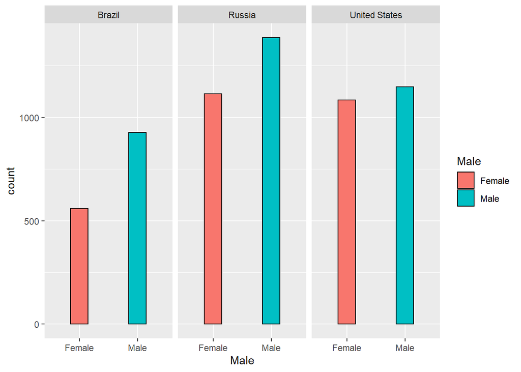

```r
# Distribution
wv2$Male = factor(wv2$Male)
wv2$Male = revalue(wv2$Male, c("0" = "Female", "1" = "Male"))

ggplot(data = wv2, mapping = aes(x = Male, fill = Male, na.rm = TRUE)) +
  geom_bar(color = "black", width = .3) +
  facet_wrap(~country)
```

#### 7) What is the distribution of the education variable? Compare for each of the three countries. Calculate as percentages.

```r
prop.table(table(wv2$Education,wv2$country), margin = 2) *100
```

```
##
##          Brazil      Russia United States
##   1  0.60893099  0.08038585    0.35842294
##   2 31.93504736  0.28135048    0.62724014
##   3 12.24627876  1.40675241    1.20967742
##   4  0.81190798  4.98392283    0.00000000
##   5  2.16508796 39.30868167    0.00000000
##   6  9.06630582  7.87781350    9.09498208
##   7 26.45466847 14.75080386   30.19713262
##   8  6.56292287  5.30546624   20.83333333
##   9 10.14884980 26.00482315   37.67921147
```

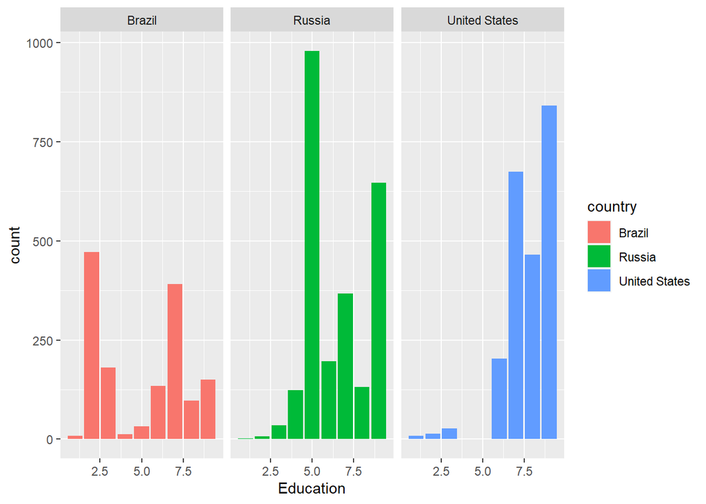

```r
ggplot(data = wv2, mapping = aes(x = Education, fill = country)) +
  geom_bar() +
  facet_wrap(~country)
```

#### 8) Create an object that contains only the data for observations from Brazil. What are the dimensions of this data object?

```r
wv_Joint <- left_join(wv, countryCodes, by = c("Country" = "V2"))
wvBrazil <- subset(wv_Joint, Country == "76")
dim(wvBrazil)
```

```
## [1] 1486   18
```

#### Bonus: calculate the mean for every column in the data set

```r
wv %>%
  summarise_if(is.numeric, mean, na.rm = TRUE)
```

```
## # A tibble: 1 x 17
##   Country SurveyYear BirthYear Satisfied Income Education Conserv Religious
##     <dbl>      <dbl>     <dbl>     <dbl>  <dbl>     <dbl>   <dbl>     <dbl>
## 1    475.      2012.     1970.      6.86   4.87      5.68    5.74      3.89
## # ... with 9 more variables: Male <dbl>, Marital <dbl>, DemocracyBad <dbl>,
## #   StrongLeaderBad <dbl>, ArmyLeaderBad <dbl>, BrazilDummy <dbl>,
## #   RussiaDummy <dbl>, UnitedStatesDummy <dbl>, age <dbl>
```